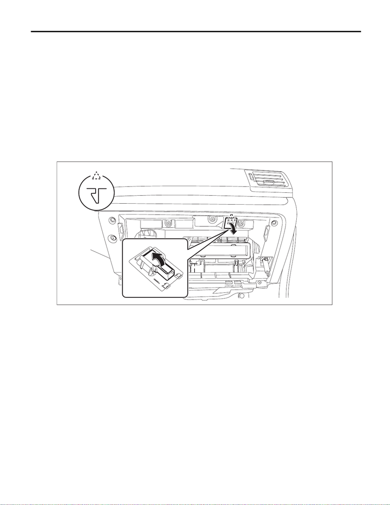

35.LED Illumination Light

A: REMOVAL

1. GLOVE BOX LIGHT

1) Disconnect the ground cable from battery. <Ref. to NT-5, BATTERY, NOTE, Note.>

NOTE:

For models other than STI model, disconnect the ground terminal from battery sensor.

2) Remove the pocket assembly. <Ref. to EI-63, REMOVAL, Glove Box.>

3) Remove the light - pocket cover.

CAUTION:

When using a flat tip screwdriver, apply protective tape or cloth and be careful not to cause damage.

(1) Release the claws.

(2) Disconnect the connector, and remove the light - pocket cover.

4) Release the claws, and remove the light - pocket.

LI-01680

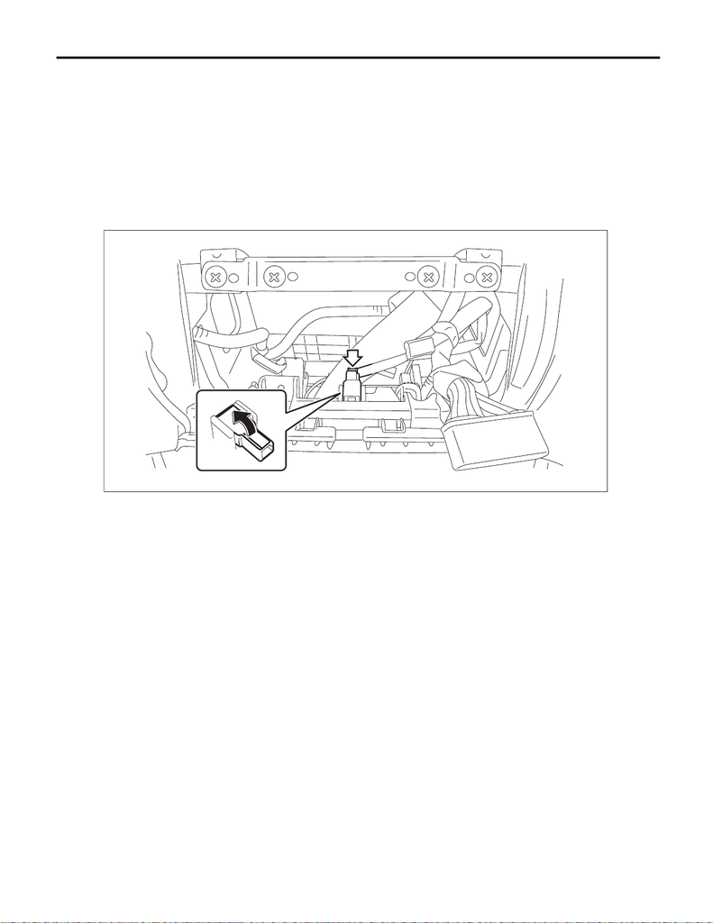

2. POCKET LIGHT

1) Disconnect the ground cable from battery. <Ref. to NT-5, BATTERY, NOTE, Note.>

NOTE:

For models other than STI model, disconnect the ground terminal from battery sensor.

2) Remove the panel center assembly. <Ref. to EI-66, REMOVAL, Center Console.>

3) Remove the light - pocket.

CAUTION:

When using a flat tip screwdriver, apply protective tape or cloth and be careful not to cause damage.

(1) Disconnect the connector.

(2) Release the claws, and remove the light - pocket.

B: INSTALLATION

1. GLOVE BOX LIGHT

1) Install the light - pocket.

2) Install the light - pocket cover.

3) Install the pocket assembly.

4) Connect the battery ground terminal. <Ref. to NT-5, BATTERY, NOTE, Note.>

NOTE:

For models other than STI model, connect the ground terminal to battery sensor.

2. POCKET LIGHT

1) Install the light - pocket.

2) Install the panel center assembly.

3) Connect the battery ground terminal. <Ref. to NT-5, BATTERY, NOTE, Note.>

NOTE:

For models other than STI model, connect the ground terminal to battery sensor.

LI-01793